# Series system with exponentially distributed component lifetimes

# Exponentially distributed component lifetimes

Consider a series system in which the components have exponentially distributed lifetimes. The $j$ component of the $i$ has a lifetime distribution given by
$$T_{i j} \sim \operatorname{EXP}(\lambda_j)$$
for $j=1,\ldots,m$. Thus, $\lambda = \bigl(\lambda_1,\ldots,\lambda_m\bigr)$. The random variable $T_{i j}$ has a reliability, pdf, and hazard function given respectively by
$$\begin{align}
\label{eq:expo_reliability}
R_j(t;\lambda_j) &= \exp(-\lambda_j t),\\
\label{eq:expo_pdf}
f_j(t;\lambda_j) &= \lambda_j \exp(-\lambda_j t),\\
\label{eq:expo_haz}
h_j(\cdot;\lambda_j) &= \lambda_j
\end{align}$$
where $t > 0$ and $\lambda_j > 0$ is the failure rate (or inverse scale) parameter.

The lifetime of the series system composed of $m$ components with exponentially distributed lifetimes has a reliability function given by
$$\begin{equation}
\label{eq:sys_expo_reliability_function}
R(t;\lambda) = \exp \biggl(-\sum_{j=1}^{m}{\lambda_j} t\biggr)
\end{equation}$$
where $t > 0$. A series system with exponentially distributed lifetimes is also exponentially distributed.

The series system’s failure rate function is given by
$$\begin{equation}
\label{eq:expo_sys_failure_rate}
h(\cdot;\lambda) = \sum_{j=1}^{m} \lambda_j
\end{equation}$$
whose proof follows from Theorem .

We see that the failure rate $\lambda = \sum_{j=1}^n \lambda$ is *constant*, consistent with the the exponential distribution being the only continuous distribution that has a constant failure rate.

The pdf of the series system is given by
$$\begin{equation}
\label{eq:expo_sys_pdf}
f(t;\lambda) = \biggl( \sum_{j=1}^{m} {\lambda_j} \biggr) \exp
\biggl(-\sum_{j=1}^{m}{\lambda_j} t\biggr)
\end{equation}$$
where $t > 0$. The conditional probability that component $k$ is the cause of a system failure at time $t$ is given by
$$\begin{equation}
\label{eq:expo_prob_K_given_S}
f_{K_i|T_i}(k|t,\lambda) = f_{K_i}(k|\lambda) =
\frac{\lambda_k}{\sum_{p=1}^{m} \lambda_p}
\end{equation}$$
where $k \in \{1,\ldots,m\}$ and $t > 0$. Due to the constant failure rates of the components, $K_i$ and $T_i$ are mutually independent. The joint pdf of $K_i$ and $T_i$ is given by
$$\begin{equation}
\label{eq:expo_joint_k_s}
f_{K_i,T_i}(k,t;\lambda) = \lambda_k \exp \biggl(-\sum_{j=1}^{m}{\lambda_j} t\biggr)
\end{equation}$$
where $k \in \{1,\ldots,m\}$ and $t > 0$.

# Statistical model

In this study, the system is a series system with $m$ components. The true DGP for the system lifetime is in the exponential series system family, i.e., the component lifetimes are exponentially and independently distributed and we denote the true parameter value by $\theta$.

The principle object of study is $\theta$, which in the case of the exponential series system family consists of $m$ rate (scale) parameters for each component lifetime, $\lambda_1, \ldots, \lambda_m$.

We are interested in estimating the $\theta$ from masked data. The masking comes in two independent forms:

- Censored system failure times, e.g., right-censoring. The system failure time is the minimum of the component lifetimes, and it is right-censored if the system failure time does not occur during the observation period,
  $$T_i = \min\{\tau_i, T_{i 1}, \ldots, T_{i m}\},$$
  where $\tau_i$ is the right-censoring time for the $i$ observation and $T_{i 1},\ldots,T_{i m}$ are the component lifetimes for the $i$th system.
- The cause of failure, the failed component, is masked. This masking comes in the form of a candidate set $\mathcal{C}_i$ that, on average, conveys information about the component cause of failure.

The candidate set $\mathcal{C}_i$ is a random variable that is a subset of $\{1,\ldots,m\}$. The true DGP for the candidate set model has a general form that may be denoted by
$$\Pr\{\mathcal{C}_i=c_i|T_1=j,\ldots,T_m,\theta,\text{other factors}\}.$$

This is a pretty complicated looking model, and we are not even interested in the DGP for candidate sets, except to the extent that it affects the sampling distribution of the MLE for $\theta$.

In theory, given some candidate set model, we could construct a joint likelihood function for the full model and jointly estimate the parameters of both the candidate set model and $\theta$. In practice, however, this could be a very challenging task unless we make some simplifying assumptions about the DGP for candidate sets.

## Candidate set models

In every model we consider, we assume that the candidate set $\mathcal{C}_i$ is only a function of the component lifetimes $T_{i 1},\ldots,T_{i m}$, $\theta$, and the right-censoring time $\tau_i$. That is, the candidate set $\mathcal{C}_i$ is independent of any other factors (or held constant for the duration of the experiment), like ambient temperature, and these factors also have a neglible effect on the series system lifetime and thus we can ignore them.

### Reduced likelihood model

In the Bernoulli candidate set model, we make the following assumptions about how candidate sets are generated:

- $C_1$: The index of the failed component is in the candidate set, i.e., $\Pr\{K_i \in \mathcal{C}_i\} = 1$, where $K_i = \arg\min_j \{ T_{i j} : j = 1,\ldots,m\}$.
- $C_2$: The probability of $C_i$ given $K_i$ and $T_i$ is equally probable when the failed component varies over the components in the candidate set, i.e., $\Pr\{\mathcal{C}_i=c_i|K_i=j,T_i=t_i,\theta\} = \Pr\{C_i=c_i|K_i=j',T_i=t_i\}$ for any $j,j' \in c_i$.
- $C_3$: The masking probabilities are conditionally independent of $\theta$ given $K_i$ and $T_i$, i.e., $\Pr\{\mathcal{C}_i=c_i|K_i=j,T_i=t_i\}$ is not a function of $\theta$.

Using these simplifying assumptions, we can arrive at a reduced likelihood function that only depends on $\theta$ and the observed data and as long as our candidate set satisfies conditions $C_1$, $C_2$, and $C_3$, our reduced likelihood function obtains the same MLEs as the full likelihood function.

We see that
$$\Pr\{\mathcal{C}_i=c_i,|K_i=j,T_i=t_i\} = g(c_i,t_i),$$
since the probability cannot depend on $j$ by condition $C_2$ and cannot depend on $\theta$ by condition $C_3$. Thus, we can write the likelihood function as
$$L(\theta) = \prod_{i=1}^n f_{T_i}(t_i|\theta) g(c_i,t_i).$$

Note, however, that different ways in which the conditions are met will yield MLEs with different sampling distributions, e.g., more or less efficient estimators.

### Bernoulli candidate set model #1

This is a special case of the reduced likelihood model. In this model, we satisfy conditions $C_1$, $C_2$, and $C_3$, but we include each of the non-failed components with a fixed probability $p$, $0 < p < 1$.

In the simplest case, $p = 0.5$, and candidate set $c_i$ has a probability given by
$$\Pr\{\mathcal{C}_i=c_i|K_i=j,T_i=t_i\} =
\begin{cases}
(1/2)^{m-1} & \text{if $j \in c_i$ and $c_i \subseteq \{1,\ldots,m\}$} \\
0 & \text{if $j \notin c_i$}.
\end{cases}$$

### Bernoulli candidate set model #2

Now, we remove condition $C_2$. We still assume conditions $C_1$ and $C_3$, but we allow $C_i$ to depend on the failed component $K_i$, i.e.,
$$\Pr\{\mathcal{C}_i=c_i|K_i=j,T_i=t_i,\theta\} \neq \Pr\{C_i=c_i|K_i=j',T_i=t_i\}$$
for $j,j' \in c_i$.

In this case, we can write the likelihood function as
$$L(\theta) = \prod_{i=1}^n f_{T_i}(t_i|\theta) \prod_{j=1}^m \Pr\{K_i=j|T_i=t_i\} \prod_{c_i \in \mathcal{C}_i} g(c_i,t_i,j).$$

# Simulation

The most straightforward series system to estimate is the series system with exponentially distributed component lifetimes.

Suppose an exponential series system with $m$ components is parameterized by the following R code:

```r
theta <- c(1,     # component 1 failure rate
           1.1,   # 3
           0.95,  # 5
           1.15,  # 6
           1.1)   # 7

m <- length(theta)
```

So, in our study, $\theta = (1, 1.1, 0.95, 1.15, 1.1)'$. The component assigned to index $j$ has an exponentially distributed lifetime with a failure rate $\theta_j$, e.g., $\theta_2 = 1.1$ is the failure rate of the component indexed by $2$.

Let’s simulate generating the lifetimes of the $m = 5$ components for this series system:

```r
set.seed(7231) # set seed for reproducibility
n <- 75
comp_times <- matrix(nrow=n,ncol=m)
for (j in 1:m)
    comp_times[,j] <- rexp(n,theta[j])
comp_times <- md_encode_matrix(comp_times,"t")
print(comp_times,n=4)
```

```
#> # A tibble: 75 × 5
#>      t1    t2      t3    t4     t5
#>   <dbl> <dbl>   <dbl> <dbl>  <dbl>
#> 1  2.95 0.782 0.132   1.77  0.0265
#> 2  1.10 0.679 0.00914 1.08  1.09
#> 3  1.20 0.352 0.658   0.928 0.921
#> 4  1.44 6.03  0.135   2.23  0.519
#> # ℹ 71 more rows
```

```r
q <- 0.25
tau <- rep(-(1/sum(theta))*log(q),n)
data <- comp_times %>% md_series_lifetime_right_censoring(tau)
print(data,n=4,drop_latent=TRUE)
```

```
#> Latent variables:  t1 t2 t3 t4 t5
#> # A tibble: 75 × 2
#>         t delta
#>     <dbl> <lgl>
#> 1 0.0265  FALSE
#> 2 0.00914 FALSE
#> 3 0.262   TRUE
#> 4 0.135   FALSE
#> # ℹ 71 more rows
```

## Masked component cause of failure

We simulate candidate sets using the Bernoulli candidate model with an appropriate set of parameters to satisfy conditions $C_1$, $C_2$, and $C_3$:

```r
p <- .3
data <- data %>% md_bernoulli_cand_C1_C2_C3(p)
print(data[,paste0("q",1:m)],n=4)
```

```
#> Latent variables:  q1 q2 q3 q4 q5 t1 t2 t3 t4 t5
#> # A tibble: 75 × 5
#>      q1    q2    q3    q4    q5
#>   <dbl> <dbl> <dbl> <dbl> <dbl>
#> 1   0.3   0.3   0.3   0.3   1
#> 2   0.3   0.3   1     0.3   0.3
#> 3   0     0     0     0     0
#> 4   0.3   0.3   1     0.3   0.3
#> # ℹ 71 more rows
```

Now, to generate candidate sets, we sample from these probabilities:

```r
data <- data %>% md_cand_sampler()
print(md_boolean_matrix_to_charsets(data,drop_set=TRUE),drop_latent=TRUE,n=6)
```

```
#> Latent variables:  q1 q2 q3 q4 q5 t1 t2 t3 t4 t5
#> # A tibble: 75 × 3
#>         t delta x
#>     <dbl> <lgl> <chr>
#> 1 0.0265  FALSE {3, 4, 5}
#> 2 0.00914 FALSE {3}
#> 3 0.262   TRUE  {}
#> 4 0.135   FALSE {3, 5}
#> 5 0.0185  FALSE {2, 3, 4}
#> 6 0.0588  FALSE {3, 4, 5}
#> # ℹ 69 more rows
```

We see that after dropping latent (unobserved) columns, we only have the right censoring time, right censoring indicator, and the candidate sets. (Note that this time we showed the candidate sets in a more friendly way using `md_boolean_matrix_to_charsets`.)

# Maximum likelihood estimation

The set of solutions to the MLE equations must be stationary points, i.e., a point at which the score function of type $\mathbb{R}^m \mapsto \mathbb{R}^m$ is zero. The $j$-th component of the output of the score function is given by
$$\begin{equation}
\label{eq:score_expo_j}
\frac{\partial \ell}{\partial \lambda_p} =
\sum_{i=1}^{n} \biggl( \sum_{j \in c_i} \lambda_j \biggr)^{-1}
1_{\{p \in c_i \text{ and } \delta_i = 0\}} - \sum_{i=1}^{n} s_i.
\end{equation}$$

We may find an MLE by solving the maximum likelihood equation , i.e., a set of (stationary) points satisfying
$$\frac{\partial \ell}{\partial \lambda_j}\Biggr|_{\hat\lambda_j} = 0$$
for $j=1,\ldots,m$. We approximate a solution to this problem by using the iterative Newton-Raphson method as described in Section .

The Newton-Raphson method needs the observed information matrix, which is a function of $\lambda$ of type $\mathbb{R}^m \mapsto \mathbb{R}^{m \times m}$. The $(j,k)$-th element of $J(\lambda)$ is given by
$$\begin{equation}
\label{eq:info_expo}
\frac{\partial^2 \ell}{\partial \lambda_j \partial \lambda_k} =
\sum_{i=1}^{n} \biggl( \sum_{j \in c_i} \lambda_j \biggr)^{-2}
1_{\{j,k \in c_i \text{ and } \delta_i = 0\}}.
\end{equation}$$

## Log-likelihood of $\theta$ given masked data

The reduced log-likelihood function (the log of the kernel of the likelihood function) is given by
$$\ell(\theta|\text{data}) =
-\left(\sum_{i=1}^{n} t_i\right)
\left(\sum_{j=1}^{m} \theta_j\right) +
\sum_{i=1}^{n} (1-\delta_i)\log\left(\sum_{j \in c_i} \theta_j\right).$$

We compute the log-likelihood function as a function of the masked data `data` with:

```r
ll <- md_loglike_exp_series_C1_C2_C3(data)
```

Note that `md_loglike_exp_series_C1_C2_c3` is implemented using minimally sufficient statistics, which improves the computational efficiency of evaluating the log-likelihood.

The log-likelihood function contains the maximum amount of information about parameter $\theta$ given the sample of masked data `data` satisfying conditions $C_1$, $C_2$, and $C_3$.

Suppose we do not know that $\theta = (1, 1.1, 0.95, 1.15, 1.1)'$. With the log-likelihood, we may estimate $\theta$ with $\hat\theta$ by solving
$$\hat{\theta} = \operatorname{argmax}_{\theta \in \Omega} \ell(\theta),$$
i.e., finding the point that *maximizes* the log-likelihood on the observed sample `data`. This is known as *maximum likelihood estimation* (MLE). We typically solve for the MLE by solving
$$\nabla \ell|_{\theta=\hat{\theta}} = 0.$$

A popular choice is gradient ascent, which is an iterative method based on the update rule
$$\theta^{(n+1)} = \theta^n + \eta \ell(\theta^n),$$
where $\eta$ is the learning rate.

We’ll show a simple way to solve this using gradient ascent. First, we need the gradient function.

```r
grad <- md_score_exp_series_C1_C2_C3(data)
```

This is a custom version for computing the gradient of the log-likelihood `md_loglike_exp_series_C1_C2_C3`. If `md_score_exp_series_C1_C2_C3` was not implemented, a simple numerical approximation of the gradient could be computed instead. More more advanced techniques, like auto-gradient type packages, may also be used, but for relatively small samples, it may not be worth the time.

In what follows, we use algebraic.mle to help solve the MLE equations and display various properties of the solution.

```r
library(stats)
theta0 <- rep(5, m)
theta.start <- sim_anneal(par=theta0, fn = ll,
    control = list(fnscale = -1, maxit = 1000L, trace = TRUE,
                   t_init = 100, .1, alpha = 0.75, it_per_temp = 10L,
                   sup = function(x) all(x > 0)))

print(theta.start$par)
```

```
#> [1] 0.4443 1.5794 1.6513 1.0773 0.4123
```

```r
print(theta.start$value)
```

```
#> [1] -11.66
```

Let’s plot the log-likelihood trace:

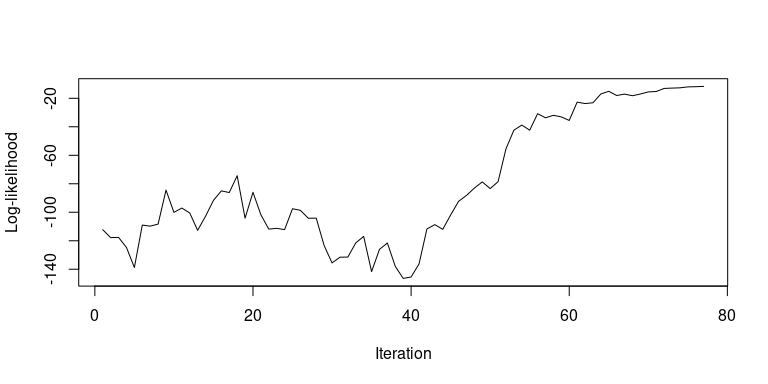

Plot of the log-likelihood.

Let’s examine its convergence plots.

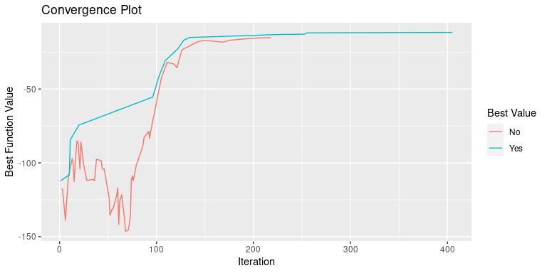

Convergence plot of the simulated annealing algorithm.

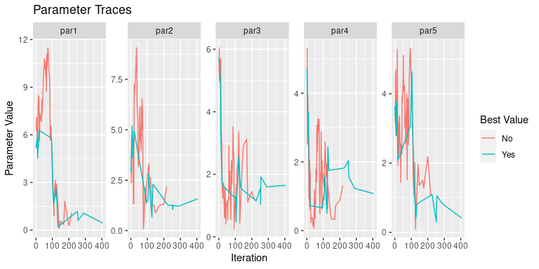

Convergence plot of the simulated annealing algorithm.

These plots demonstrate the exploration vs. exploitation trade-off of the simulated annealing algorithm. Initially, the algorithm explores the parameter space quite liberally, accepting very poor solutions, but as the temperature decreases, it begins to be more selective, only accepting solutions that are better or at least not much worse than the current solution, and eventually it only accepts better solutions.

```r
res <- optim(par = theta0, fn = ll, method = "L-BFGS-B",
    lower = 1e-3, hessian = TRUE,
    control = list(fnscale = -1, maxit = 1000, trace = 1, REPORT = 1))
estimate <- mle_numerical(res)
```

This is a constructor for `mle` objects. We can get a summary of the object with:

```r
summary(estimate)
```

```
#> Maximum likelihood estimator of type mle_numerical is normally distributed.
#> The estimates of the parameters are given by:
#> [1] 0.5816 1.1083 1.6782 1.3695 0.5727
#> The standard error is  0.3382 0.4153 0.5174 0.5047 0.4088 .
#> The asymptotic 95% confidence interval of the parameters are given by:
#>            2.5% 97.5%
#> param1  0.02526 1.138
#> param2  0.42525 1.791
#> param3  0.82714 2.529
#> param4  0.53942 2.200
#> param5 -0.09963 1.245
#> The MSE of the estimator is  0.9764 .
#> The log-likelihood is  -10.72 .
#> The AIC is  31.44 .
```

We let `theta.hat` be given by the `point` method, which obtains the point $\hat{\theta}$.

```r
(theta.hat <- point(estimate))
```

```
#> [1] 0.5816 1.1083 1.6782 1.3695 0.5727
```

We see that
$$\hat{\theta} = (0.5816, 1.1083, 1.6782, 1.3695, 0.5727)'.$$
Recall that the true parameter is $\theta = (1, 1.1, 0.95, 1.15, 1.1)'$.

Due to sampling variability, different runs of the experiment will result in different outcomes, i.e., $\hat{\theta}$ has a sampling distribution. We see that $\hat{\theta} \neq \theta$, but it is reasonably close. We may measure this sampling variability using the variance-covariance matrix, bias, mean squared error (MSE), and confidence intervals.

## Log-likelihood profile

If we let the $\theta_2,\ldots,\theta_m$ in log-likelihood function be fixed at their maximum likelihood estimates, then we may profile the log-likelihood function over $\theta_1$ to get a better sense of the shape of the log-likelihood function.

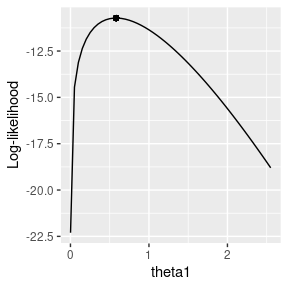

# Sampling distribution of the MLE

The MLE $\hat{\theta}$ as a function of a random sample of masked data, and is thus a random vector.

A primary statistic of an estimator is its *confidence interval*. A $(1-\alpha)100\%$ confidence interval for $\theta_j$ may be estimated with $\hat\theta_j \pm z_{1-\alpha/2} \sqrt{\hat{V}_{j j}}$. We provide a method for doing this calculation:

```r
confint(estimate)
```

```
#>            2.5% 97.5%
#> param1  0.02526 1.138
#> param2  0.42525 1.791
#> param3  0.82714 2.529
#> param4  0.53942 2.200
#> param5 -0.09963 1.245
```

Theoretically, $\hat{\theta}$ converges in distribution to the multivariate normal with a mean $\theta$ and variance-covariance matrix $J^{-1}(\theta)$. We may estimate $\theta$ with $\hat\theta$A and we may estimate the variance-covariance with the inverse of the observed Fisher matrix, which is given by
$$J(\hat{\theta}) = -\nabla^2 l|_{\hat{\theta}}.$$
Thus, approximately,
$$\hat{\theta} \sim \mathcal{N}(\theta,J^{-1}(\hat{\theta})).$$

Asymptotically, $\hat{\theta}$ is the UMVUE, i.e., it is unbiased and obtains the minimum sampling variance. An estimate of the variance-covariance may be obtained with:

```r
(V.hat <- vcov(estimate))
```

```
#>           [,1]      [,2]     [,3]      [,4]      [,5]
#> [1,]  0.114398 -0.008881 -0.01088 -0.006763 -0.033688
#> [2,] -0.008881  0.172463 -0.02114 -0.037185 -0.002002
#> [3,] -0.010882 -0.021137  0.26774 -0.042240 -0.037126
#> [4,] -0.006763 -0.037185 -0.04224  0.254689 -0.040911
#> [5,] -0.033688 -0.002002 -0.03713 -0.040911  0.167086
```

## Bias and mean squared error

We would like to measure the accuracy and precision of $\hat{\theta}$. In statistical literature, the bias
$$\operatorname{b}(\hat{\theta}) = E(\hat{\theta}) - \theta$$
is a measure of accuracy and variance is a measure of precision.

The mean squared error, denoted by $\operatorname{MSE}$, is a measure of estimator error that incorporates both the bias and the variance,
$$\operatorname{MSE}(\hat{\theta}) =
\operatorname{trace}\bigl(\operatorname{vcov}(\hat{\theta})\bigr) +
\operatorname{b}^2(\hat{\theta}).$$

Since $\hat{\theta}$ is asymptotically unbiased and minimum variance,
$$\lim_{n \to \infty} \operatorname{MSE}(\hat{\theta}) =
\operatorname{trace}\bigl(\operatorname{vcov}(\hat{\theta})\bigr).$$
Thus, for sufficiently large samples, $\operatorname{MSE}(\hat{\theta})$ is approximately given by the `trace` of the estimated variance-covariance matrix:

```r
(mse <- sum(diag(V.hat)))
```

```
#> [1] 0.9764
```

If we have a sample of $n$ MLEs, $\hat{\theta}^{(1)},\ldots,\hat{\theta}^{(n)}$, then we may estimate both the bias and the MSE respectively with the statistics
$$\hat{\operatorname{b}} = \frac{1}{n} \sum_{i=1} \hat{\theta}^{(i)} - \theta$$
and
$$\widehat{\operatorname{MSE}} = \frac{1}{n}
\sum_{i=1}^n (\hat{\theta}^{(i)} - \theta)
(\hat{\theta}^{(i)} - \theta)'.$$
We may then compare these statistics, $\hat{\operatorname{b}}$ and $\widehat{\operatorname{MSE}}$, with the asymptotic bias $({0})$ and the asymptotic $\operatorname{MSE}$.

```r
#stats1 <- readr::read_csv2("./data-raw/exp_series_stats_1.csv")
```

## Estimating the variance-covariance using the Bootstrap method

Alternatively, we could estimate $\theta$ with $B$ simulated draws from the MLEs that satisfy
$$\operatorname{argmax}_{\theta \in \Omega} \ell(\theta|\mathcal{D_i})$$
where $\mathcal{{D_i}}$ is a random sample from the empirical distribution $\{(S_i,\delta_i,C_i)\}_1^n$. We call this the *Bootstrap*.

Assuming the above solution to the MLE equation is *unique*, this gives us a single point $\hat{\theta}_{(i)}$ when conditioned on the simulated masked data ${D_i}$.

```r
bias(estimate)
```

[output not shown]

# Candidate sets that generate non-unique MLEs

In some cases, the MLE may be non-unique due to a small sample size. However, there are cases where as the sample size $n \to \infty$, the MLE remains non-unique, i.e., it is not guaranteed to converge to any value. One way in which this can occur for a series system with masked component causes of failure is given by the following setup.

Let the exponential series system consist of $m=3$ components. Components $1$ and $2$ are on the same circuit board, and component $3$ is on another circuit board. Whenever the series system fails, the potential components that may have caused the failure is determined by replacing the entire circuit board. Thus, when compoent $1$ or $2$ fails, the series system is fixed by replacing the circuit board they both reside on, and thus the candidate set is $\{1,2\}$. If component $3$ fails, the candidate set is $\{3\}$. In this case, the log-likelihood function is given by
$$\ell(\lambda_1,\lambda_2,\lambda_3) = \eta_3 \log(\lambda_3) +
\eta_{1 2} \log(\lambda_1+\lambda_2) -
(\eta_3+\eta_{1 2}) \bar{s} (\lambda_1+\lambda_2+\lambda_3),$$
where $\eta_3$ denotes the number of observations in which the candidate set is $\{3\}$ and $\eta_{1 2}$ denotes the number of observations in which the candidate set is $\{1,2\}$.

Let $\hat{\lambda}_1 = 1$, $\hat{\lambda}_2 = 2$, and $\hat{\lambda}_3 = 3$. Then,
$$\ell(1,2,3) = \eta_3 \log(3) +
\eta_{1 2} \log(1+2) -
(\eta_3+\eta_{1 2}) \bar{s}(1+2+3).$$
However, if we interchange the values for $\hat{\lambda}_1$ and $\hat{\lambda}_2$, we get the same value for the log-likehood function. Thus, any time $(\hat{\lambda}_1,\hat{\lambda}_2,\hat{\lambda}_3)$ is an MLE, so is $(\hat{\lambda}_2,\hat{\lambda}_1,\hat{\lambda}_3)$. This is known as *non-identifiability*, which means that two or more values of the parameters result in the same likelihood of the observed data.

To find an MLE, we take the derivative of $\ell$ with respect to the parameters, obtaining the simultaneous equations
$$\begin{align}
\hat\lambda_1 + \hat\lambda_2 &= \frac{\eta_{1 2}}{(\eta_{1 2} + \eta_3) \bar{s}}\\
\hat\lambda_3 &= \frac{\eta_3}{(\eta_{1 2} + \eta_3) \bar{s}}
\end{align}$$
We see that
$$\hat\lambda_1 + \hat\lambda_2 =\frac{\eta_{1 2}}{(\eta_{1 2} + \eta_3) \bar{s}}$$
defines a *line*, and thus any point on this line is an MLE of $\hat\lambda_1$ and $\hat\lambda_2$.

# Bootstrap stuff

Now, we find the MLE with the following R code:

```r
loglike.exp <- md_loglike_exp_series_C1_C2_C3(md)
lambda.hat <- algebraic.mle::mle_gradient_ascent(
    l=loglike.exp,
    theta0=lambda)
points <- cbind(point(lambda.hat),as.matrix(lambda))
colnames(points) <- c("MLE","Parameter")
cbind(points,confint(lambda.hat))
```

TODO: I show a bunch of different estimates, like bias and confidence intervals, using the Bootstrap method. I need to work on presenting only interesting estimates in a way that helps show what the MLE is like for small samples, then show how as the sample gets larger, we become consistent with the asymptotic theory of the MLE. So, basically a graph whose x-axis is sample size and whose y-axis is MSE or bias.

```r
N <- c(100,200,300,400,500)
for (n in N)
{
    md <- tibble(t1=stats::rexp(n,rate=lambda[1]),
                 t2=stats::rexp(n,rate=lambda[2]),
                 t3=stats::rexp(n,rate=lambda[3])) %>%
        md_series_lifetime() %>%
        md_bernoulli_candidate_C1_C2_C3(m)

    loglike.exp <- md_loglike_exp_series_C1_C2_C3(md)
    loglike.scr <- md_score_exp_series_C1_C2_C3(md)
    mle.exp <- mle_gradient_ascent(l=loglike.exp,theta0=lambda,score=loglike.scr)
    mle.boot <- mle_boot_loglike(mle=mle.exp,
                                 loglike.gen=md_loglike_exp_series_C1_C2_C3,
                                 data=md)

    cat("Sample size: ", n, "\n")
    cat("---------------\n")

    print("Estimate of bias using Bootstrap:")
    print(bias(mle.boot,lambda))

    print("Estimate of confidence intervals:")
    print("Asymptotic")
    print(confint(mle.exp))
    print("Bootstrap")
    print(confint(mle.boot))

    print("Estimate of variance-covariance:")
    print("Asymptotic")
    print(vcov(mle.exp))
    print("Bootstrap")
    print(vcov(mle.boot))

    print("Estimate of MSE:")
    print("Asymptotic")
    print(mse(mle.exp))
    print("Bootstrap")
    print(mse(mle.boot,lambda))
}
```

# Sensitivity analysis

How sensitive is our MLE to sampling conditions? In particular, how sensitive is it when we vary the way the candidate sets are generated? First, let’s vary the parameter $p$ in the Bernoulli candidate model.

The most informative sample when only changing $p$ is given by letting $p=0$, i.e., we know the exact component cause of failure.

```r
data.best <- comp_times %>%
    md_series_lifetime_right_censoring(tau) %>%
    md_bernoulli_cand_C1_C2_C3(p=0) %>%
    md_cand_sampler()
```

Here’s what the new sample looks like:

```r
print(md_boolean_matrix_to_charsets(data.best,drop_set=TRUE),drop_latent=TRUE)
```

```
#> Latent variables:  q1 q2 q3 q4 q5 t1 t2 t3 t4 t5
#> # A tibble: 75 × 3
#>          t delta x
#>      <dbl> <lgl> <chr>
#>  1 0.0265  FALSE {5}
#>  2 0.00914 FALSE {3}
#>  3 0.262   TRUE  {}
#>  4 0.135   FALSE {3}
#>  5 0.0185  FALSE {2}
#>  6 0.0588  FALSE {3}
#>  7 0.107   FALSE {1}
#>  8 0.262   TRUE  {}
#>  9 0.0965  FALSE {2}
#> 10 0.101   FALSE {2}
#> # ℹ 65 more rows
```

It’s the same as the previous sample, except that we see that we either have only empty candidate sets (the system was right-censored) or candidate sets that only contain the failed component (in order to satisfy the condition that the failed component must be in the candidate set).

Let’s compute the log-likelihood and MLEs for this new sample:

```r
ll.best <- md_loglike_exp_series_C1_C2_C3(data.best)
start.best <- algebraic.mle::sim_anneal(
    fn=ll.best,
    par=theta0,
    options=list(
        t_init=100,
        t_end=.001,
        alpha=.95,
        maxit=10000,
        it_per_temp=100,
        fnscale=-1,
        sup=function(theta) all(theta > 0),
        trace=FALSE))

sol <- stats::optim(par = start.best$value,
    fn = ll.best, method = "BFGS", fnscale = -1)
estimate.best <- mle_numerical(sol=sol)
as_tibble(confint(estimate.best)) %>% mutate(mle=point(estimate.best),theta=theta)
```

[output not shown]

```r
ci <- confint(estimate)
ci.best <- confint(estimate.best)

length <- ci[,2] - ci[,1]
length.best <- ci.best[,2] - ci.best[,1]
diff <- point(estimate) - theta
diff.best <- point(estimate.best) - theta
tibble(theta=theta) %>%
    mutate("CI length ratio (length(best)/length(old)"=length.best/length) %>%
    mutate("mle(best)"=point(estimate.best)) %>%
    mutate("mle(old)"=point(estimate)) %>%
    mutate("error(mle(best))"=diff.best) %>%
    mutate("error(mle(old))"=diff)
```

[output not shown]

If *no* information is provided about the component cause of failure in a series system, then the estimator is not unique and does not converge to $\theta$. However, let’s do it anyway:

```r
data.worst <- comp_times %>%
    md_series_lifetime_right_censoring(tau) %>%
    md_bernoulli_cand_C1_C2_C3(p=1) %>%
    md_cand_sampler()

ll.worst <- md_loglike_exp_series_C1_C2_C3(data.worst)
estimate.worst <- mle_numerical(ll.worst, theta0=theta)
as_tibble(confint(estimate.worst)) %>% mutate(mle=point(estimate.worst),theta=theta)
```

[output not shown]

Here’s what the new sample looks like:

```r
print(md_boolean_matrix_to_charsets(data.worst,drop_set=TRUE),drop_latent=TRUE)
```

[output not shown]

# Estimating component cause

Another characteristic we may wish to estimate is the probability that a particular component in an observation caused the system failure.

We wish to use as much information as possible to do this estimation. We consider three cases:

1. We have masked data `data` with candidate sets and system failure times and seek to estimate the node failure probabilities of observations in this data. This case provides the most accurate estimates of the node probability failures, as have both system failure times and candidate sets as predictors of the node failure.
2. We have a new observation of a system failure time and an estimate of $\theta$ from `data`. In this case, we cannot condition on candidate sets, since the observation does not include that information. However, we do have a system failure time.
3. We have an estimate of $\theta$ from `data` but wish to predict the node failure of a system that has failed, but we do not know when it failed.

We consider case 1 described above where we have masked data `data` that includes both candidate sets and system failure times.

In this case, we are interested in
$$f_{K_i|C_i,T_i}(j|c_i,t_i,\theta) = \frac{h_j(t;{\theta_k})}{\sum_{j' \in c_i} h_{j'}(t_i;{\theta_{j'}})},$$
which in the exponential series case simplifies to
$$f_{K_i|C_,T_i}(j|c_i,t_i,\theta) = \frac{{\theta_j}}{\sum_{j' \in c_i} {\theta_{j'}}}.$$

We decorate `md` with this probability distribution with the decorator function `md_series_component_failure_probability`, which accepts masked data as input and returns the masked data with columns for component cause of failure probabilities given by `k1`,…,`km`.

```r
#h <- list(function(t) theta.hat[1],
#          function(t) theta.hat[2],
#          function(t) theta.hat[3])
#md %>% md_series_component_failure_probability_decorator(h)
```

If we already had an estimate of $\theta$ and we sought to predict the failed components from only system lifetime data, we would just let the candidate sets contain all of the component indexes.

Also, observe that the component failure probabilities
$$\hat{ k}_i(\theta) = (\hat{k}_1,\hat{k}_2,\hat{k}_3)'$$
is a random vector whose sampling distribution under the right conditions is a multivariate normal whose $j$ component is given by
$$\hat{k}_j \sim \mathcal{N}(f_{K_i|T_i}(j|t_i,\theta),\Sigma_i).$$
We can simulate $n$ draws from $\hat{\theta}$ and then apply the above statistic of interest, generating the data
$$\hat{ k}^{(1)},\ldots,\hat{ k}^{(n)}.$$